# Variante Effect Prediction with VEP followed by tidying with R

This is an [R Markdown](http://rmarkdown.rstudio.com) Notebook.

Written by Megan McDonald on July 3rd 2024, with assistance from ChatGPT. The goal of this notebook is to take a filtered VCF file and run this through ensembls VEP (variant effect prediction) tool. This will assign functions to all SNPs/Indels present in the VCF file.

The second part of this notebook takes the VEP annotation file and combines this with a gene deletion file. Gene deletions are assigned as “HIGH” effect variants.

The final part of this notebook generates filtered output tables looking at MODERATE and HIGH impact mutations/gene deletions in all isolates.

```r
library(tidyverse)
library(readr)
```

### The file “filtered_variant_effect.txt” is the text output from VEP from ensemble.

1. Note you will need to change the individuals to match the genotype names in your filtered.vcf. file.
2. VEP only takes numbers for chromosome names, so you may need to modify your reference accordingly.

vep -i allnumeric.filtered.vcf –gff data.gff.gz –fasta genome.fa.gz –distance 500 –individual ISOLATE1,ISOATE2,ISOLATE3 –force_overwrite filter_vep -i variant_effect_output.txt -o filtered_variant_effect.txt -filter “IMPACT is not MODIFIER” –force_overwrite

```r
input_file <- "filtered_variant_effect.txt"
data <- read_tsv(input_file, comment = "##", show_col_types = FALSE)
```

```r
data2 <- data %>%
  separate(Uploaded_variation, into = c("Chromosome", "Position", "Alleles"), sep = "_") %>%
  separate(Alleles, into = c("Ref", "Alt"), sep="/")
```

```r
data3 <- data2 %>%
  mutate(Extra = str_replace_all(Extra, ";", "&")) %>%
  separate(Extra, into = c("IND", "ZYG", "IMPACT", "STRAND", "SOURCE"), sep = "&") %>%
  mutate(IND = str_remove(IND, "IND="),
         ZYG = str_remove(ZYG, "ZYG="),
         IMPACT = str_remove(IMPACT, "IMPACT="),
         STRAND = str_remove(STRAND, "STRAND="),
         SOURCE = str_remove(SOURCE, "SOURCE="))
```

```r
data_wide <- data3 %>%
  pivot_wider(names_from = IND, values_from = ZYG, values_fill = list(ZYG = "REF"))
```

```r
individuals <- c("A_S68_B_1","A_S68_B_2","A_S68_B_3","A_S68_B_4","A_S71_A_1",
                 "B_S14_A_1","B_S14_B_1","B_S14_C_1","B_S23_A_1","B_S23_B_1",
                 "B_S23_C_1","B_S27_A_2","B_S27_B_1","B_S27_C_1","UV80_1",
                 "UV80_2","UV80_3","UV80_4")

data_wide <- data_wide %>%
  mutate(across(all_of(individuals), ~ifelse(. == "HOM", 1, 0)))
```

```r
# Select the desired columns and create the final table
final_table <- data_wide %>%
  select(Chromosome, Position, Ref, Alt, Gene, Consequence, IMPACT, cDNA_position, CDS_position, Amino_acids, Codons, all_of(individuals))

final_table <- final_table %>%
  mutate(IMPACT = factor(IMPACT, levels = c("HIGH", "MODERATE", "LOW")),
         Chromosome = factor(Chromosome, levels = as.character(1:21)))

# Save the final table to a new file
write_tsv(final_table, "tidy_filtered_variant_effect.txt")
```

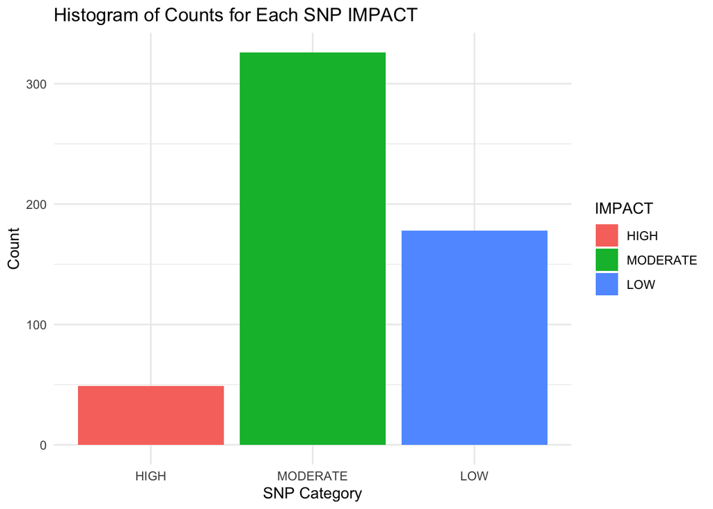

```r
Impact_summary <- ggplot(final_table, aes(x = IMPACT)) +
  geom_histogram(aes(fill=IMPACT),stat = "count") +
  theme_minimal() +
  labs(title = "Histogram of Counts for Each SNP IMPACT",
       x = "SNP Category",
       y = "Count")
Impact_summary
```

```r
ggsave("SNP_Impacts.pdf", Impact_summary, dpi=600, units = "cm", width = 10, height = 10)
```

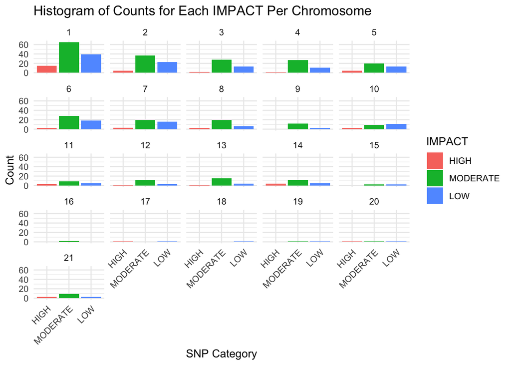

```r
# Generate histogram for IMPACT counts per Chromosome
Impact_per_Chromosome<- ggplot(final_table, aes(x = IMPACT)) +
  geom_histogram(aes(fill=IMPACT), stat = "count") +
  facet_wrap(~ Chromosome) +
  theme_minimal() +
  labs(title = "Histogram of Counts for Each IMPACT Per Chromosome",
       x = "SNP Category",
       y = "Count") +
  theme(axis.text.x = element_text(angle = 45, hjust = 1))
Impact_per_Chromosome
```

```r
ggsave("All_SNP_Impacts_by_Chr.pdf", Impact_per_Chromosome, dpi=600, units = "cm", width = 20, height = 15)
```

```r
gene_presence_absence_file <- "../06_coverage/genes/combined_summary.txt"

# Step 1: Import the gene presence-absence data

gene_data <- read_tsv(gene_presence_absence_file, col_types = cols(
  Chrom = col_character(),
  Start = col_double(),
  Stop = col_double(),
  Gene = col_character(),
  .default = col_double()
))

# Remove the "IPO323_chr_" prefix from the Chromosome column
gene_data <- gene_data %>%
  mutate(Chrom = str_remove(Chrom, "IPO323_chr_"))

# Step 2: Transform the gene presence-absence data
# Extract relevant information from the Gene column and create a unified format
gene_data <- gene_data %>%
  mutate(Chromosome = Chrom,
         Position = Start,
         Gene = str_extract(Gene, "gene_[0-9]+"),
         Consequence = "gene deletion",
         IMPACT = "HIGH") %>%
  select(Chromosome, Position, Gene, Consequence, IMPACT, starts_with("A_"), starts_with("B_"), starts_with("UV"))
```

## Combine the Gene Deletion file and the SNPs Variante Effect Files into one large Dataframe.

## Gene deletions have “HIGH” impact assigned to them.

```r
# Step 3: Combine the two datasets
# Ensure the final_table has the same column names for individuals
final_table <- final_table %>%
  select(Chromosome, Position, Gene, Consequence, IMPACT, starts_with("A_"), starts_with("B_"), starts_with("UV"))%>%
  mutate(Position= as.numeric(Position))

# Combine the datasets
combined_data <- bind_rows(final_table, gene_data)

# Ensure the Chromosome column is a factor with levels ordered from 1 to 21
combined_data <- combined_data %>%
  mutate(Chromosome = factor(Chromosome, levels = as.character(1:21)))

# Ensure the combined data is sorted by Chromosome and Position
combined_data <- combined_data %>%
  arrange(Chromosome, as.numeric(Position))



# Save the combined data to a new file
write_tsv(combined_data, "combined_snp_gene_data.txt")

# How many genes are impacted
length(unique(combined_data$Gene))
```

```
## [1] 799
```

```r
combined_data[combined_data$IMPACT=="MODERATE",3]
```

| Gene |
| --- |
| gene_20 |
| gene_20 |
| gene_45 |
| gene_65 |
| gene_115 |
| gene_233 |
| gene_265 |
| gene_314 |
| gene_347 |
| gene_458 |

[output cut: 316 more lines]

```r
combined_data[combined_data$IMPACT=="HIGH",3]
```

| Gene |
| --- |
| gene_314 |
| gene_382 |
| gene_489 |
| gene_738 |
| gene_901 |
| gene_1008 |
| gene_1008 |
| gene_1450 |
| gene_1538 |
| gene_1553 |

[output cut: 386 more lines]

```r
combined_data[combined_data$IMPACT=="LOW",3]
```

| Gene |
| --- |
| gene_20 |
| gene_175 |
| gene_299 |
| gene_302 |
| gene_314 |
| gene_316 |
| gene_316 |
| gene_366 |
| gene_366 |
| gene_495 |

[output cut: 168 more lines]

## Make histogram plots again including gene deletions

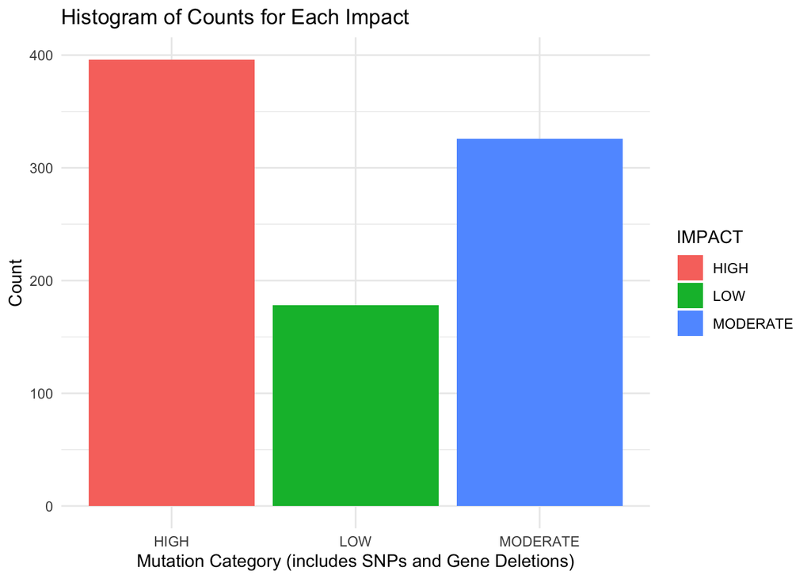

```r
Impact_summary_SNPandGD <- ggplot(combined_data, aes(x = IMPACT)) +
  geom_histogram(aes(fill=IMPACT),stat = "count") +
  theme_minimal() +
  labs(title = "Histogram of Counts for Each Impact",
       x = "Mutation Category (includes SNPs and Gene Deletions)",
       y = "Count")
Impact_summary_SNPandGD
```

```r
ggsave("SNPandGD_Impacts.pdf", Impact_summary_SNPandGD, dpi=600, units = "cm", width = 15, height = 10)
```

## Sort through this combined list to find any genes that have a high or moderate impact in the mutants with the GoV phenotype but not the other sequenced controls.

```r
# Step 1: Filter for MODERATE or HIGH impacts
high_moderate_impact_data <- combined_data %>%
  filter(IMPACT %in% c("HIGH", "MODERATE"))

# Step 2: Identify columns representing individuals
individuals <- names(high_moderate_impact_data)[grepl("A_|B_|UV", names(high_moderate_impact_data))]

# Step 3: Exclude genes where UV80_1, UV80_2, UV80_3, or UV80_4 have a 1 genotype
uv_individuals <- c("UV80_1", "UV80_2", "UV80_3", "UV80_4", "A_S68_B_3", "A_S71_A_1")
filtered_data <- high_moderate_impact_data %>%
  filter(rowSums(across(all_of(uv_individuals), ~ . == 1)) == 0)

# Step 4: Combine the genotypes across duplicate rows for each gene
combined_genotypes <- filtered_data %>%
  group_by(Gene, Chromosome) %>%
  summarise(across(all_of(individuals), ~ max(.)), .groups = 'drop')

# Step 5: Summarize the data to count the number of individuals with a 1 for each gene
gene_impact_summary <- combined_genotypes %>%
  rowwise() %>%
  mutate(Count = sum(c_across(all_of(individuals)) == 1)) %>%
  ungroup() %>%
  filter(Count >= 2) %>%
  select(Gene, Count, all_of(individuals))

# Step 6: Create a reference dataframe for Gene and Chromosome
gene_chromosome_lookup <- filtered_data %>%
  select(Gene, Chromosome) %>%
  distinct()

# Step 7: Merge Chromosome information back to gene_impact_summary
gene_impact_summary <- gene_impact_summary %>%
  left_join(gene_chromosome_lookup, by = "Gene") %>%
  select(Chromosome, Gene, Count, all_of(individuals))


# Print the summary
print(gene_impact_summary)
```

```
## # A tibble: 299 × 21
##    Chromosome Gene       Count A_S68_B_1 A_S68_B_2 A_S68_B_3 A_S68_B_4 A_S71_A_1
##    <fct>      <chr>      <int>     <dbl>     <dbl>     <dbl>     <dbl>     <dbl>
##  1 5          gene_10011     3         1         1         0         1         0
##  2 5          gene_10018     3         0         0         0         0         0
##  3 5          gene_10060     2         0         0         0         0         0
##  4 6          gene_10181     2         0         0         0         0         0
##  5 6          gene_10215     2         0         0         0         0         0
##  6 6          gene_10259     3         1         1         0         1         0
##  7 6          gene_10350     3         0         0         0         0         0
##  8 6          gene_10361     3         1         1         0         1         0
##  9 6          gene_10363     3         0         0         0         0         0
## 10 1          gene_1041      3         1         1         0         1         0
## # ℹ 289 more rows
## # ℹ 13 more variables: B_S14_A_1 <dbl>, B_S14_B_1 <dbl>, B_S14_C_1 <dbl>,
## #   B_S23_A_1 <dbl>, B_S23_B_1 <dbl>, B_S23_C_1 <dbl>, B_S27_A_2 <dbl>,
## #   B_S27_B_1 <dbl>, B_S27_C_1 <dbl>, UV80_1 <dbl>, UV80_2 <dbl>, UV80_3 <dbl>,
## #   UV80_4 <dbl>
```

```r
# Save the summary to a new file
write_tsv(gene_impact_summary, "gene_impact_summary_moderate_high_filtered.txt")
```